# Arboles de Decision

## Modelo de validación cruzada

```r
# Configurar la validación cruzada (en 10 folds)
control <- trainControl(method = "cv", number = 10)
# Entrenar el modelo usando validación cruzada
modelo_cv <- train(Category ~ . ,
                   data = data,
                   method = "rpart",
                   trControl = control, na.action = na.pass)

# Mostrar resultados
print(modelo_cv)
```

```
## CART
##
## 1460 samples
##   80 predictor
##    3 classes: 'Baratas', 'Caras', 'Medianas'
##
## No pre-processing
## Resampling: Cross-Validated (10 fold)
## Summary of sample sizes: 1314, 1313, 1314, 1314, 1314, 1315, ...
## Resampling results across tuning parameters:
##
##   cp          Accuracy   Kappa
##   0.01832994  0.8171169  0.5929328
##   0.05023761  0.7842166  0.4724045
##   0.35234216  0.7144654  0.2073029
##
## Accuracy was used to select the optimal model using the largest value.
## The final value used for the model was cp = 0.01832994.
```

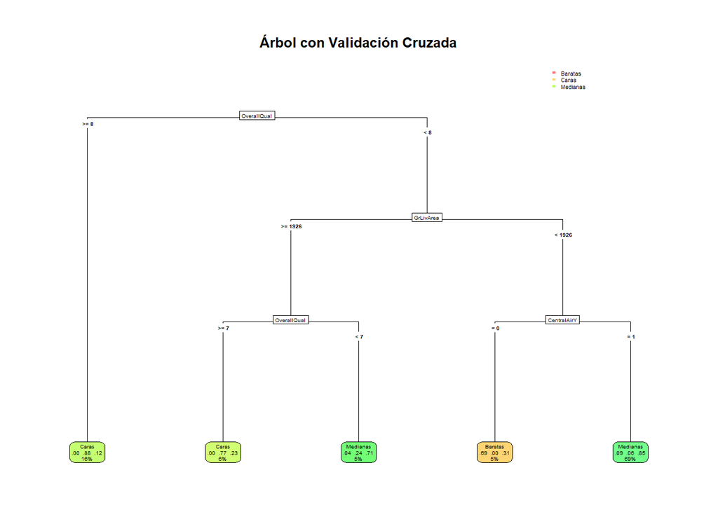

```r
# Gráfica del modelo ajustado
rpart.plot(modelo_cv$finalModel, type = 5, extra = 104, fallen.leaves = TRUE,
           cex = 0.30, box.palette = "RdYlGn", main = "Árbol con Validación Cruzada")
```

El modelo de validación cruzada tiene similitudes con el árbol anterior pues primero determina la calidad de los acabados de la vivienda, sin embargo evalua distintas variables luego para calificar el precio de la casa.

## Predicciones con el modelo dde validación

```r
new_pred <- predict(modelo_cv, newdata = test, na.action = na.pass)
new_conf <- confusionMatrix(new_pred, test$Category)
new_conf
```

```
## Confusion Matrix and Statistics
##
##           Reference
## Prediction Baratas Caras Medianas
##   Baratas       16     0        3
##   Caras          0    67       13
##   Medianas      18    24      187
##
## Overall Statistics
##
##                Accuracy : 0.8232
##                  95% CI : (0.7775, 0.8629)
##     No Information Rate : 0.6189
##     P-Value [Acc > NIR] : 6.942e-16
##
##                   Kappa : 0.6422
##
##  Mcnemar's Test P-Value : NA
##
## Statistics by Class:
##
##                      Class: Baratas Class: Caras Class: Medianas
## Sensitivity                 0.47059       0.7363          0.9212
## Specificity                 0.98980       0.9451          0.6640
## Pos Pred Value              0.84211       0.8375          0.8166
## Neg Pred Value              0.94175       0.9032          0.8384
## Prevalence                  0.10366       0.2774          0.6189
## Detection Rate              0.04878       0.2043          0.5701
## Detection Prevalence        0.05793       0.2439          0.6982
## Balanced Accuracy           0.73019       0.8407          0.7926
```

Este modelo es un poco peor que el anterior pues el accuracy es de 0.82, además, ahora solamente acertó correctamente a las casas baratas en el 47% de los casos y en las casas caras en el 74% de los casos, por lo que tampoco es tan bueno como el anterior clasificando casas medianas y caras. El error en las casas baratas es bastante significativo pues en más de la mitad de los casos da un resultado equivocado